# Analyze AEA Survey with Weights

## 1.4 Section 4

### 1.4.1 Question 1

What is the largest percentage of significance mismatch you would accept before…?

```r
aea_weighted %>%
  group_by(is.na(Q4_1_1)) %>%
  summarize(n())
```

| is.na(Q4_1_1) | n() |
| --- | --- |
| FALSE | 473 |
| TRUE | 544 |

```r
aea_weighted %>%
  group_by(is.na(Q4_1_2)) %>%
  summarize(n())
```

| is.na(Q4_1_2) | n() |
| --- | --- |
| FALSE | 467 |
| TRUE | 550 |

```r
probs <- c(0, 0.05, 0.25, 0.5, 0.75, 0.95, 1)

aea_weighted %>%
  summarize(
    sig_mismatch = survey_quantile(Q4_1_1, quantiles = probs, na.rm = TRUE)
  )
```

| sig_mismatch_q00 | sig_mismatch_q05 | sig_mismatch_q25 | sig_mismatch_q50 | sig_mismatch_q75 | sig_mismatch_q95 | sig_mismatch_q100 | sig_mismatch_q00_se | sig_mismatch_q05_se | sig_mismatch_q25_se | sig_mismatch_q50_se | sig_mismatch_q75_se | sig_mismatch_q95_se | sig_mismatch_q100_se |
| --- | --- | --- | --- | --- | --- | --- | --- | --- | --- | --- | --- | --- | --- |
| 0 | 0 | 5 | 10 | 20 | 50 | 100 | 0.2544526 | 0.2544526 | 1.272263 | 2.544526 | 2.544526 | 12.46818 | NaN |

```r
aea_weighted %>%
  summarize(
    sig_mismatch = survey_quantile(Q4_1_2, quantiles = probs, na.rm = TRUE)
  )
```

| sig_mismatch_q00 | sig_mismatch_q05 | sig_mismatch_q25 | sig_mismatch_q50 | sig_mismatch_q75 | sig_mismatch_q95 | sig_mismatch_q100 | sig_mismatch_q00_se | sig_mismatch_q05_se | sig_mismatch_q25_se | sig_mismatch_q50_se | sig_mismatch_q75_se | sig_mismatch_q95_se | sig_mismatch_q100_se |
| --- | --- | --- | --- | --- | --- | --- | --- | --- | --- | --- | --- | --- | --- |
| 0 | 0.5 | 5 | 10 | 20 | 50 | 100 | 0.2544442 | 0.2544442 | 1.272221 | 2.544442 | 2.544442 | 11.44999 | NaN |

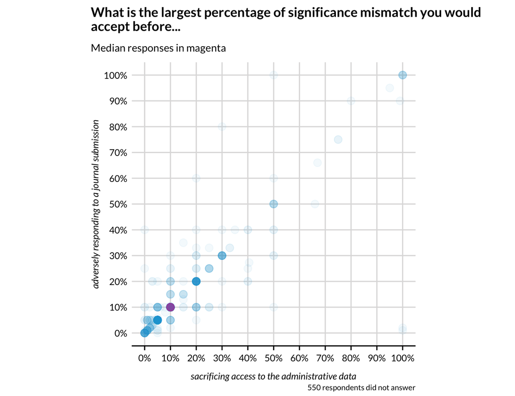

```r
missing_q4.1 <- sum(is.na(pull(aea_weighted, Q4_1_1)) | is.na(pull(aea_weighted, Q4_1_2)))

ggplot() +
  geom_point(
    data = aea_weighted$variables,
    mapping = aes(Q4_1_1 / 100, Q4_1_2 / 100),
    alpha = 0.05
  ) +
  geom_point(
    data = summarize(aea_weighted,
                     Q4_1_1 = survey_median(Q4_1_1, na.rm = TRUE),
                     Q4_1_2 = survey_median(Q4_1_2, na.rm = TRUE)),
    mapping = aes(Q4_1_1 / 100, Q4_1_2 / 100),
    alpha = 0.5,
    color = "#ec008b"
  ) +
  scale_x_continuous(breaks = seq(0, 1, 0.1), labels = scales::percent_format(accuracy = 1)) +
  scale_y_continuous(breaks = seq(0, 1, 0.1), labels = scales::percent_format(accuracy = 1)) +
  scatter_grid() +
  coord_equal() +
  labs(
    title = "What is the largest percentage of significance mismatch you would\naccept before...",
    subtitle = "Median responses in magenta",
    x = "sacrificing access to the administrative data",
    y = "adversely responding to a journal submission",
    caption = paste(missing_q4.1, "respondents did not answer")
  )
```

### 1.4.2 Question 2

What is the largest percentage of sign mismatch you would accept before…?

*This is more conservative than significance, which seems good.*

```r
aea_weighted %>%
  group_by(is.na(Q4_2_1)) %>%
  summarize(n())
```

| is.na(Q4_2_1) | n() |
| --- | --- |
| FALSE | 470 |
| TRUE | 547 |

```r
aea_weighted %>%
  group_by(is.na(Q4_2_2)) %>%
  summarize(n())
```

| is.na(Q4_2_2) | n() |
| --- | --- |
| FALSE | 465 |
| TRUE | 552 |

```r
probs <- c(0, 0.05, 0.25, 0.5, 0.75, 0.95, 1)

aea_weighted %>%
  summarize(
    sign_mismatch = survey_quantile(Q4_2_1, quantile = probs, na.rm = TRUE)
  )
```

| sign_mismatch_q00 | sign_mismatch_q05 | sign_mismatch_q25 | sign_mismatch_q50 | sign_mismatch_q75 | sign_mismatch_q95 | sign_mismatch_q100 | sign_mismatch_q00_se | sign_mismatch_q05_se | sign_mismatch_q25_se | sign_mismatch_q50_se | sign_mismatch_q75_se | sign_mismatch_q95_se | sign_mismatch_q100_se |
| --- | --- | --- | --- | --- | --- | --- | --- | --- | --- | --- | --- | --- | --- |
| 0 | 0 | 0.1 | 5 | 10 | 30 | 100 | 0.2544484 | 0.2544484 | 0.2544484 | 1.272242 | 2.544484 | 5.088968 | NaN |

```r
aea_weighted %>%
  summarize(
    sign_mismatch = survey_quantile(Q4_2_2, quantile = probs, na.rm = TRUE)
  )
```

| sign_mismatch_q00 | sign_mismatch_q05 | sign_mismatch_q25 | sign_mismatch_q50 | sign_mismatch_q75 | sign_mismatch_q95 | sign_mismatch_q100 | sign_mismatch_q00_se | sign_mismatch_q05_se | sign_mismatch_q25_se | sign_mismatch_q50_se | sign_mismatch_q75_se | sign_mismatch_q95_se | sign_mismatch_q100_se |
| --- | --- | --- | --- | --- | --- | --- | --- | --- | --- | --- | --- | --- | --- |
| 0 | 0 | 1 | 5 | 10 | 25 | 100 | 0.2544413 | 0.2544413 | 1.017765 | 1.272207 | 2.544413 | 5.088826 | NaN |

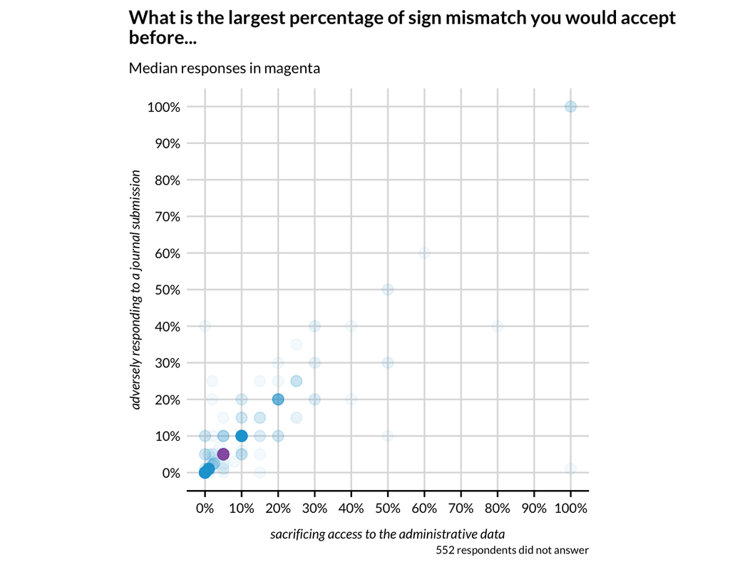

```r
missing_q4.2 <- sum(is.na(pull(aea_weighted, Q4_2_1)) | is.na(pull(aea_weighted, Q4_2_2)))

ggplot() +
  geom_point(
    data = aea_weighted$variables,
    mapping = aes(Q4_2_1 / 100, Q4_2_2 / 100),
    alpha = 0.05
  ) +
  geom_point(
    data = summarize(
      aea_weighted,
      Q4_2_1 = survey_median(Q4_2_1, na.rm = TRUE),
      Q4_2_2 = survey_median(Q4_2_2, na.rm = TRUE)
    ),
    mapping = aes(Q4_2_1 / 100, Q4_2_2 / 100),
    alpha = 0.5,
    color = "#ec008b"
  ) +
  scale_x_continuous(breaks = seq(0, 1, 0.1), labels = scales::percent_format(accuracy = 1)) +
  scale_y_continuous(breaks = seq(0, 1, 0.1), labels = scales::percent_format(accuracy = 1)) +
  scatter_grid() +
  coord_equal() +
  labs(
    title = "What is the largest percentage of sign mismatch you would accept\nbefore...",
    subtitle = "Median responses in magenta",
    x = "sacrificing access to the administrative data",
    y = "adversely responding to a journal submission",
    caption = paste(missing_q4.2, "respondents did not answer")
  )
```

### 1.4.3 Question 3

What is the highest amount of absolute relative bias you would accept in an estimate before…?

```r
aea_weighted %>%
  group_by(is.na(Q4_3_1)) %>%
  summarize(n())
```

| is.na(Q4_3_1) | n() |
| --- | --- |
| FALSE | 453 |
| TRUE | 564 |

```r
aea_weighted %>%
  group_by(is.na(Q4_3_2)) %>%
  summarize(n())
```

| is.na(Q4_3_2) | n() |
| --- | --- |
| FALSE | 450 |
| TRUE | 567 |

```r
probs <- c(0, 0.05, 0.25, 0.5, 0.75, 0.95, 1)

aea_weighted %>%
  summarize(
    abs_relative_error = survey_quantile(Q4_3_1, quantiles = probs, na.rm = TRUE)
  )
```

| abs_relative_error_q00 | abs_relative_error_q05 | abs_relative_error_q25 | abs_relative_error_q50 | abs_relative_error_q75 | abs_relative_error_q95 | abs_relative_error_q100 | abs_relative_error_q00_se | abs_relative_error_q05_se | abs_relative_error_q25_se | abs_relative_error_q50_se | abs_relative_error_q75_se | abs_relative_error_q95_se | abs_relative_error_q100_se |
| --- | --- | --- | --- | --- | --- | --- | --- | --- | --- | --- | --- | --- | --- |
| 0 | 0 | 5 | 10 | 20 | 50 | 150 | 0.2544236 | 0.2544236 | 1.272118 | 2.544236 | 1.272118 | 12.72118 | NaN |

```r
aea_weighted %>%
  summarize(
    abs_relative_error = survey_quantile(Q4_3_2, quantiles = probs, na.rm = TRUE)
  )
```

| abs_relative_error_q00 | abs_relative_error_q05 | abs_relative_error_q25 | abs_relative_error_q50 | abs_relative_error_q75 | abs_relative_error_q95 | abs_relative_error_q100 | abs_relative_error_q00_se | abs_relative_error_q05_se | abs_relative_error_q25_se | abs_relative_error_q50_se | abs_relative_error_q75_se | abs_relative_error_q95_se | abs_relative_error_q100_se |
| --- | --- | --- | --- | --- | --- | --- | --- | --- | --- | --- | --- | --- | --- |
| 0 | 0.05 | 5 | 10 | 20 | 50 | 150 | 0.2544191 | 0.2544191 | 1.272095 | 2.544191 | 1.272095 | 12.72095 | NaN |

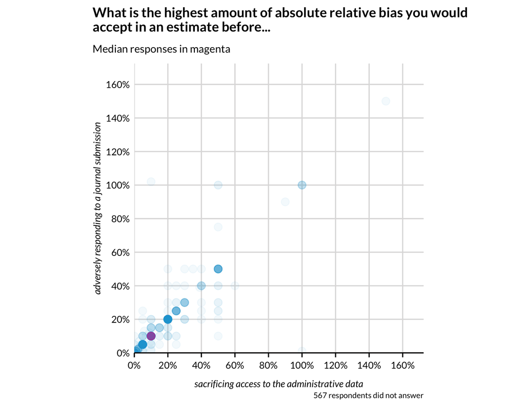

```r
missing_q4.3 <- sum(is.na(pull(aea_weighted, Q4_3_1)) | is.na(pull(aea_weighted, Q4_3_2)))

ggplot() +
  geom_point(
    data = aea_weighted$variables,
    mapping = aes(Q4_3_1 / 100, Q4_3_2 / 100),
    alpha = 0.05
  ) +
  geom_point(
    data = summarize(
      aea_weighted,
      Q4_3_1 = survey_median(Q4_3_1, na.rm = TRUE),
      Q4_3_2 = survey_median(Q4_3_2, na.rm = TRUE)
    ),
    mapping = aes(Q4_3_1 / 100, Q4_3_2 / 100),
    alpha = 0.5,
    color = "#ec008b"
  ) +
  scale_x_continuous(
    breaks = seq(0, 1.6, 0.2),
    expand = expansion(mult = c(0, 0.15)),
    labels = scales::percent_format(accuracy = 1)
  ) +
  scale_y_continuous(
    breaks = seq(0, 1.6, 0.2),
    expand = expansion(mult = c(0, 0.15)),
    labels = scales::percent_format(accuracy = 1)
  ) +
  scatter_grid() +
  coord_equal() +
  labs(
    title = "What is the highest amount of absolute relative bias you would\naccept in an estimate before...",
    subtitle = "Median responses in magenta",
    x = "sacrificing access to the administrative data",
    y = "adversely responding to a journal submission",
    caption = paste(missing_q4.3, "respondents did not answer")
  )
```

### 1.4.4 Question 4

What is the largest confidence interval ratio you would accept in an estimate before…?

```r
aea_weighted %>%
  group_by(is.na(Q4_4_1)) %>%
  summarize(n())
```

| is.na(Q4_4_1) | n() |
| --- | --- |
| FALSE | 445 |
| TRUE | 572 |

```r
aea_weighted %>%
  group_by(is.na(Q4_4_2)) %>%
  summarize(n())
```

| is.na(Q4_4_2) | n() |
| --- | --- |
| FALSE | 442 |
| TRUE | 575 |

```r
probs <- c(0, 0.05, 0.25, 0.5, 0.75, 0.95, 1)

aea_weighted %>%
  summarize(
    ci_ratio = survey_quantile(Q4_4_1, quantiles = probs, na.rm = TRUE)
  )
```

| ci_ratio_q00 | ci_ratio_q05 | ci_ratio_q25 | ci_ratio_q50 | ci_ratio_q75 | ci_ratio_q95 | ci_ratio_q100 | ci_ratio_q00_se | ci_ratio_q05_se | ci_ratio_q25_se | ci_ratio_q50_se | ci_ratio_q75_se | ci_ratio_q95_se | ci_ratio_q100_se |
| --- | --- | --- | --- | --- | --- | --- | --- | --- | --- | --- | --- | --- | --- |
| 1 | 1 | 1.1 | 1.25 | 2 | 25 | 10000 | 0.01272057 | 0.01272057 | 0.02544113 | 0.0763234 | 0.763234 | 12.21174 | NaN |

```r
aea_weighted %>%
  summarize(
    ci_ratio = survey_quantile(Q4_4_2, quantiles = probs, na.rm = TRUE)
  )
```

| ci_ratio_q00 | ci_ratio_q05 | ci_ratio_q25 | ci_ratio_q50 | ci_ratio_q75 | ci_ratio_q95 | ci_ratio_q100 | ci_ratio_q00_se | ci_ratio_q05_se | ci_ratio_q25_se | ci_ratio_q50_se | ci_ratio_q75_se | ci_ratio_q95_se | ci_ratio_q100_se |
| --- | --- | --- | --- | --- | --- | --- | --- | --- | --- | --- | --- | --- | --- |
| 1 | 1 | 1.1 | 1.25 | 2 | 30 | 100000 | 0.01272033 | 0.01272033 | 0.02544066 | 0.07632198 | 0.7632198 | 17.80846 | 0 |

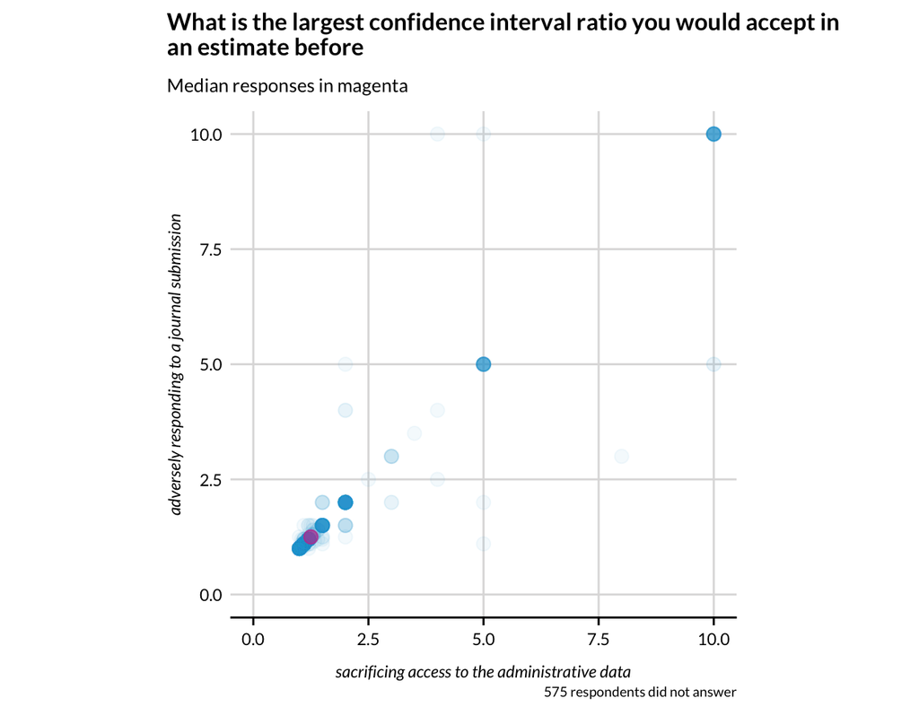

```r
missing_q4.4 <- sum(is.na(pull(aea_weighted, Q4_4_1)) | is.na(pull(aea_weighted, Q4_4_2)))

ggplot() +
  geom_point(
    data = aea_weighted$variables,
    mapping = aes(Q4_4_1, Q4_4_2),
    alpha = 0.05
  ) +
  geom_point(
    data = summarize(
      aea_weighted,
      Q4_4_1 = survey_median(Q4_4_1, na.rm = TRUE),
      Q4_4_2 = survey_median(Q4_4_2, na.rm = TRUE)
    ),
    mapping = aes(Q4_4_1, Q4_4_2),
    alpha = 0.5,
    color = "#ec008b"
  ) +
  scale_x_continuous(limits = c(0, 10)) +
  scale_y_continuous(limits = c(0, 10)) +
  scatter_grid() +
  coord_equal() +
  labs(
    title = "What is the largest confidence interval ratio you would accept in\nan estimate before",
    subtitle = "Median responses in magenta",
    x = "sacrificing access to the administrative data",
    y = "adversely responding to a journal submission",
    caption = paste(missing_q4.4, "respondents did not answer")
  )
```

## 1.5 Section 5

### 1.5.1 Question 1

5.1: Suppose you gain access to administrative data for regression analysis, but your access is constrained by a privacy budget. How would you spend your privacy budget from the following choices?

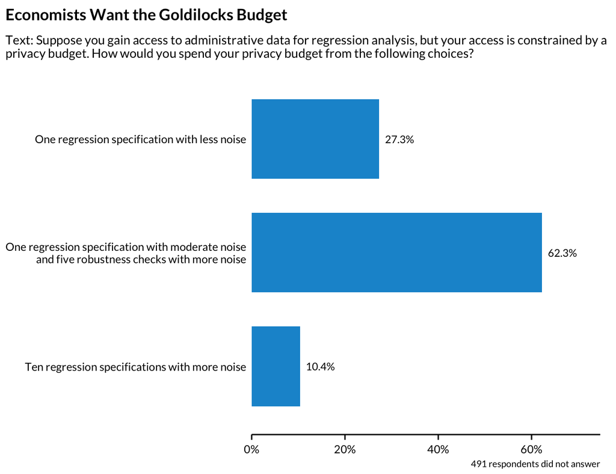

```r
missing_q5.1 <- sum(is.na(pull(aea_weighted, Q5_1)))

aea_weighted %>%
  filter(!is.na(Q5_1)) %>%
  group_by(Q5_1) %>%
  summarize(n(), survey_prop(vartype = "ci")) %>%
  mutate(Q5_1 = fct_recode(
    Q5_1,
    `One regression specification with moderate noise\nand five robustness checks with more noise` =
      "One regression specification with moderate noise and five robustness checks with more   noise")
  ) %>%
  mutate(Q5_1 = fct_rev(Q5_1)) %>%
  ggplot(aes(coef, Q5_1)) +
  geom_col() +
  geom_text(aes(label = label_percent(accuracy = 0.1)(coef)), hjust = -0.2) +
  scale_x_continuous(
    labels = scales::percent,
    expand = expansion(mult = c(0, 0.2))
  ) +
  labs(
    title = "Economists Want the Goldilocks Budget",
    subtitle = "Text: Suppose you gain access to administrative data for regression analysis, but your access is constrained by a\nprivacy budget. How would you spend your privacy budget from the following choices?",
    x = NULL,
    y = NULL,
    caption = paste(missing_q5.1, "respondents did not answer")
  ) +
  theme(panel.grid = element_blank())
```

## 1.6 Software